# The Project

1. This is a project with minimal scaffolding. Expect to use the the discussion forums to gain insights! It’s not cheating to ask others for opinions or perspectives!
2. Be inquisitive, try out new things.
3. Use the previous modules for insights into how to complete the functions! You'll have to combine Pillow, OpenCV, and Pytesseract
4. There are hints provided in Coursera, feel free to explore the hints if needed. Each hint provide progressively more details on how to solve the issue. This project is intended to be comprehensive and difficult if you do it without the hints.

### The Assignment

Take a ZIP file) of images and process them, using a [library built into python](https://docs.python.org/3/library/zipfile.html) that you need to learn how to use. A ZIP file takes several different files and compresses them, thus saving space, into one single file. The files in the ZIP file we provide are newspaper images (like you saw in week 3). Your task is to write python code which allows one to search through the images looking for the occurrences of keywords and faces. E.g. if you search for "pizza" it will return a contact sheet of all of the faces which were located on the newspaper page which mentions "pizza". This will test your ability to learn a new ([library](https://docs.python.org/3/library/zipfile.html)), your ability to use OpenCV to detect faces, your ability to use tesseract to do optical character recognition, and your ability to use PIL to composite images together into contact sheets.

Each page of the newspapers is saved as a single PNG image in a file called images.zip. These newspapers are in english, and contain a variety of stories, advertisements and images. Note: This file is fairly large (~200 MB) and may take some time to work with, I would encourage you to use small_img.zip for testing.

Here's an example of the output expected. Using the small_img.zip file, if I search for the string "Christopher" I should see the following image:

[figure not shown]

If I were to use the images.zip file and search for "Mark" I should see the following image (note that there are times when there are no faces on a page, but a word is found!):

[figure not shown]

Note: That big file can take some time to process - for me it took nearly ten minutes! Use the small one for testing.

```python
from zipfile import ZipFile
from IPython.core.debugger import set_trace

from kraken import pageseg
from PIL import Image, ImageDraw, ImageFont, ImageChops, ImageEnhance
import pytesseract
import cv2 as cv
import numpy as np

# data source
IMAGEDATA_LIB = {}

img_data_src = "readonly/images.zip"
#img_data_src = "readonly/small_img.zip"


# loading the face detection classifier
face_cascade = cv.CascadeClassifier('readonly/haarcascade_frontalface_default.xml')
```

```python
class ImageData():
    """
    Class that holds a PIL image, a cv image (array) and a dictionary that contains
    locations of bounding boxes for faces and all the ocr text found in the image as string

    img_data: contains keys "txt", "faces" holds ocr text and
    locations of faces (bounding boxes defined by [x0, y0, x1, y1] 2 corners of rect)
    """

    def __init__(self, orig_img, ocr_img, cv_img):
        self.img = orig_img
        self.ocr_img = ocr_img
        self.cv_img = cv_img
        self.img_data = {"txt": [], "faces": []}
```

```python
with ZipFile(img_data_src, 'r') as z:
    for name in z.namelist():
        print(name)
        orig_img = Image.open(z.open(name))  # original color image
        cv_img = cv.cvtColor(cv.imread(name), cv.COLOR_BGR2GRAY)  # gray scale cv_image for face detect

        cv_ocr = cv.threshold(cv_img, 127, 255, cv.THRESH_BINARY)[1]
        ocr_img = Image.fromarray(cv_ocr)  # BW PIL-image for ocr

        IMAGEDATA_LIB[name] = ImageData(orig_img, ocr_img, cv_img)
```

```
a-0.png
a-1.png
a-10.png
a-11.png
a-12.png
a-13.png
a-2.png
a-3.png
a-4.png
a-5.png
a-6.png
a-7.png
a-8.png
a-9.png
```

```python
def process_image_for_text(imagedata_obj):
    """ Given an ImageData object run the image through ocr and face detection
    and update the object's img_data dict
    """
    ocr_txt = pytesseract.image_to_string(imagedata_obj.ocr_img)
    ocr_txt = ocr_txt.replace("\n", ' ')
    imagedata_obj.img_data["txt"] = ocr_txt

def process_image_for_faces(imagedata_obj):
    faces = face_cascade.detectMultiScale(imagedata_obj.cv_img,1.3,5)
    for face in faces:
        imagedata_obj.img_data["faces"].append(np.add(face, [0, 0, face[0], face[1]]).tolist())
```

```python
def draw_all_faces(imagedata_obj):
    """ Given an ImageData object return a contact sheet (Image) of all the faces found in the image
    cropepd to 120x120 thumbnails.
    """
    faces = imagedata_obj.img_data["faces"]  # list of lists
    size_thumb = 120  # max size of face thumbnail
    mode = imagedata_obj.img.mode

    if(len(faces) == 0):
        return None

    # iterate through bound boxes of faces and get cropped faces
    crop_faces = []
    for x0, y0, x1, y1 in faces:
        crop_faces.append(imagedata_obj.img.crop((x0, y0, x1, y1)))

    width = 5 * size_thumb
    height = ((len(faces) // 5) + (1 if len(faces) % 5 > 0 else 0)) * size_thumb
    contact_sheet = Image.new(mode, (width, height))

    x=0
    y=0
    for face in crop_faces:
        # resize to thumb
        if face.width > size_thumb or face.height > size_thumb:
            face.thumbnail((size_thumb, size_thumb), resample=Image.LANCZOS)

        # Lets paste the current image into the contact sheet
        contact_sheet.paste(face, (x, y) )
        # Now we update our X position. If it is going to be the width of the image, then we set it to 0
        # and update Y as well to point to the next "line" of the contact sheet.
        if x + size_thumb == contact_sheet.width:
            x = 0
            y += size_thumb
        else:
            x += size_thumb
    return contact_sheet
```

```python
for image_name in IMAGEDATA_LIB:
    print("converting text in ", image_name)
    process_image_for_text(IMAGEDATA_LIB[image_name])
```

```
converting text in  a-0.png
converting text in  a-1.png
converting text in  a-10.png
converting text in  a-11.png
converting text in  a-12.png
converting text in  a-13.png
converting text in  a-2.png
converting text in  a-3.png
converting text in  a-4.png
converting text in  a-5.png
converting text in  a-6.png
converting text in  a-7.png
converting text in  a-8.png
converting text in  a-9.png
```

```python
for image_name in IMAGEDATA_LIB:
    print("getting faces in ", image_name)
    process_image_for_faces(IMAGEDATA_LIB[image_name])
```

```
getting faces in  a-0.png
getting faces in  a-1.png
getting faces in  a-10.png
getting faces in  a-11.png
getting faces in  a-12.png
getting faces in  a-13.png
getting faces in  a-2.png
getting faces in  a-3.png
getting faces in  a-4.png
getting faces in  a-5.png
getting faces in  a-6.png
getting faces in  a-7.png
getting faces in  a-8.png
getting faces in  a-9.png
```

```python
def search_wrd_get_faces(IMAGEDATA_LIB, wrd):
    """ Input a list of ImageData objects and search if word 'wrd'
    appeared in the ocr text. If the word was present in the object's img_data dict
    return the contact sheet of all the faces found for that object
    '"""
    for imagedata_obj_name in IMAGEDATA_LIB:

        image_obj = IMAGEDATA_LIB.get(imagedata_obj_name)

        if wrd in image_obj.img_data["txt"]:
            print("Results found in file {}".format(imagedata_obj_name))
            contact_sheet_faces = draw_all_faces(image_obj)
            if contact_sheet_faces is not None:
                display(contact_sheet_faces)
            else:
                print("But there were no faces in that file!")
```

[output not shown]

[figure not shown]

[output not shown]

[figure not shown]

```python
search_wrd_get_faces(IMAGEDATA_LIB, "Christopher")
```

[output not shown]

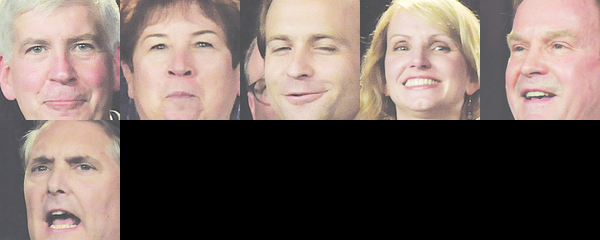

[output not shown]

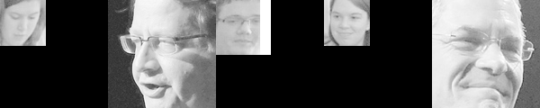

[output not shown]

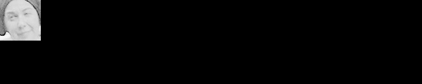

[output not shown]

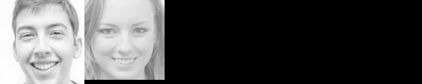

[output not shown]

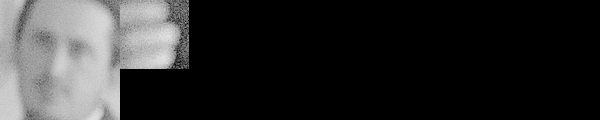

[output not shown]

```python
search_wrd_get_faces(IMAGEDATA_LIB, "Mark")
```

[output not shown]